# The Bachelor/Bachelorette

2024-03-07

## R Markdown

```r
library(tidyverse)
library(janitor)
library(here)
```

Data of all 41 seasons of The BAchelor and The Bachelortte:

```r
season_details <- read.csv("data/season_details.csv")
```

1. Structure of this data set:

```r
glimpse(season_details)
```

```
## Rows: 41
## Columns: 9
## $ show           <chr> "Bachelor", "Bachelor", "Bachelor", "Bachelor", "Bachel…
## $ season         <int> 1, 2, 3, 4, 5, 6, 7, 8, 9, 10, 11, 12, 13, 14, 15, 16, …
## $ start_date     <chr> "2002-03-25", "2002-09-25", "2003-03-24", "2003-09-24",…
## $ full_name      <chr> "Alex Michel", "Aaron Buerge", "Andrew Firestone", "Bob…
## $ occupation     <chr> "Management Consultant", "Banker", "Winery Co-Owner", "…
## $ hometown       <chr> "Charlottesville, Virginia", "Springfield, Missouri", "…
## $ age            <int> 31, 28, 28, 32, 25, 40, 29, 34, 34, 30, 35, 28, 32, 32,…
## $ proposal       <lgl> FALSE, TRUE, TRUE, FALSE, FALSE, TRUE, FALSE, FALSE, FA…
## $ still_together <lgl> FALSE, FALSE, FALSE, FALSE, FALSE, FALSE, FALSE, FALSE,…
```

2. New data set that only contains the seasons in which the couples are still together:

```r
still_together<- season_details%>%
  group_by(season, full_name, still_together)%>%
  filter(still_together=="TRUE")
```

3. How many couples, from all 41 seasons, are still together?

```r
Bachelor<- still_together%>%
  filter(show=="Bachelor")%>%
  count(still_together, show)
```

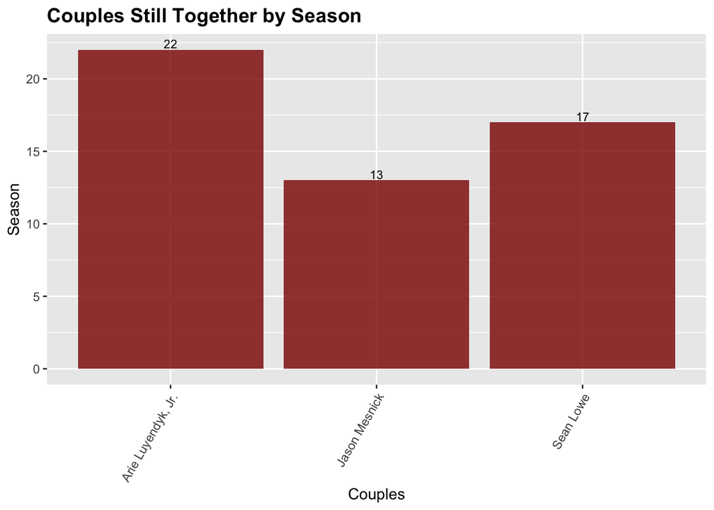

```r
Bachelor%>%
  ggplot(aes(x=season, y=full_name))+
  geom_col(fill = "darkred", alpha=0.8)+
  coord_flip()+
  labs(title="Couples Still Together by Season", x="Season", y="Couples")+
  theme(axis.text.x = element_text(angle = 60, hjust = 1),
        plot.title = element_text(size = 14, face="bold"))+
  geom_text(aes(label = season), vjust = -0.2, size = 3, color = "black")
```

```r
Bachelorette<- still_together%>%
  filter(show=="Bachelorette")%>%
  count(still_together, show)
```

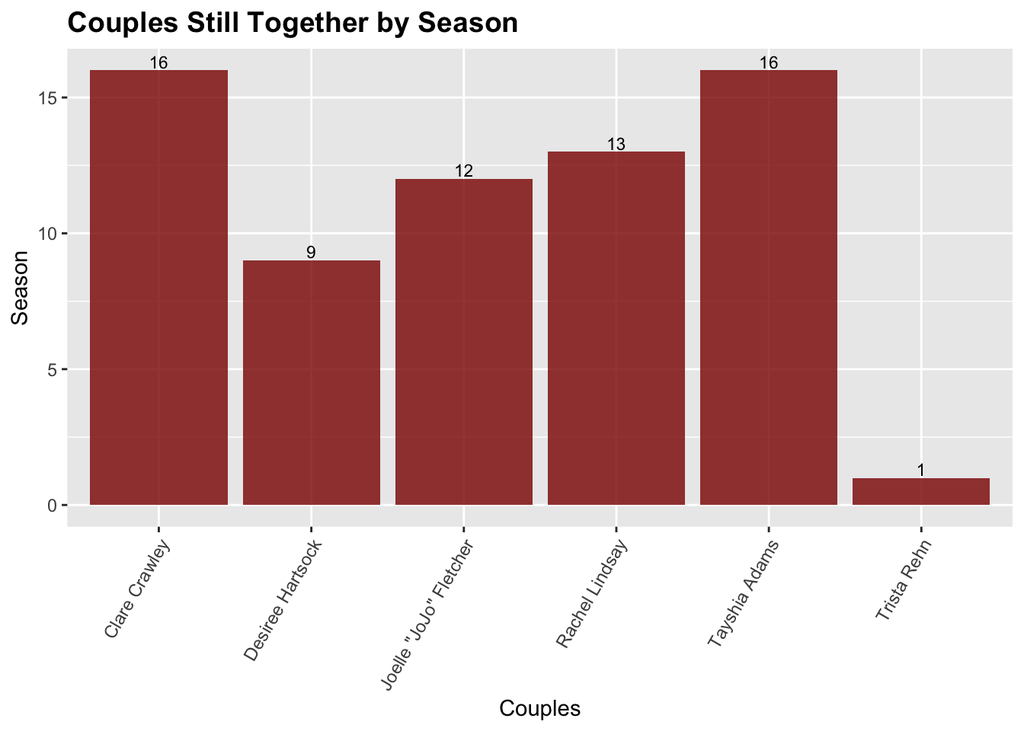

```r
Bachelorette%>%
  ggplot(aes(x=season, y=full_name))+
  geom_col(fill = "darkred", alpha=0.8)+
  coord_flip()+
  labs(title="Couples Still Together by Season", x="Season", y="Couples")+
  theme(axis.text.x = element_text(angle = 60, hjust = 1),
        plot.title = element_text(size = 14, face="bold"))+
  geom_text(aes(label = season), vjust = -0.2, size = 3, color = "black")
```

4. Make a plot to show the number of couples still together by season.

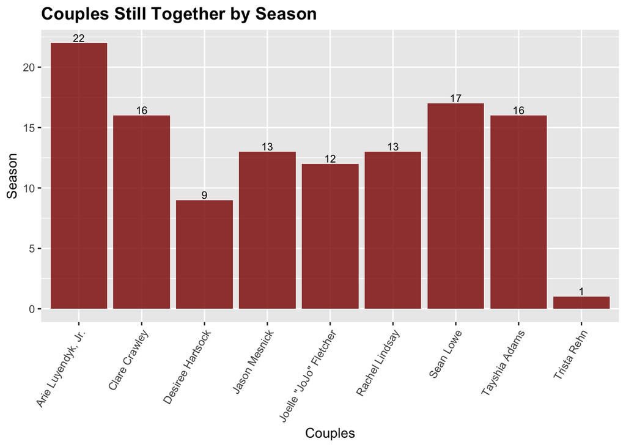

```r
ggplot(still_together, aes(x=season, y=full_name))+
  geom_col(fill = "darkred", alpha=0.8)+
  coord_flip()+
  labs(title="Couples Still Together by Season", x="Season", y="Couples")+
  theme(axis.text.x = element_text(angle = 60, hjust = 1),
        plot.title = element_text(size = 14, face="bold"))+
  geom_text(aes(label = season), vjust = -0.2, size = 3, color = "black")
```

5. Make a plot that shows all of the couples.

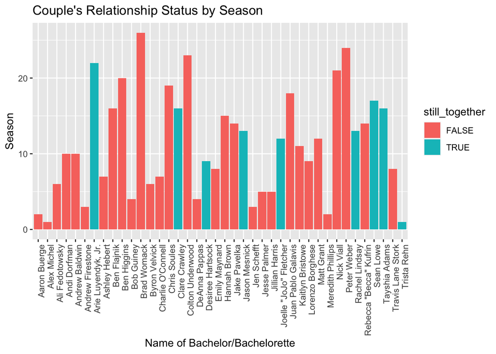

```r
ggplot(season_details, aes(x=season, y=full_name, fill=still_together))+
  geom_col()+
  coord_flip()+
  labs(title="Couple's Relationship Status by Season", x="Season", y="Name of Bachelor/Bachelorette")+
  theme(axis.text.x=element_text(angle=90, hjust = 1))
```

Data Set 2 which shows the hometowns of the last few contestants in each season:

```r
hometowns <- read.csv("data/hometown_coordinates.csv")
```

Data set 3 which shows the contestants that got eliminated throughout each season:

```r
eliminations <- read.csv("data/eliminations_and_dates.csv")
```

Data set 4 which shows the names of all the contestants in each season:

```r
contestants <- read.csv("data/contestant_details.csv")
```

6. How many contestants are in each season?

```r
contestants%>%
count(full_name, season)
```

```
##                         full_name season n
## 1                      AJ Yalawan     16 1
## 2                              AW      3 1
## 3                           Aaron      2 1
## 4                   Aaron Martell      8 1
## 5                            Abby      6 1
## 6                Abigail Heringer     25 1
## 7                  Adam Duvendeck      5 1
## 8                 Adam Gottschalk     13 1
## 9        Adrianne "Jane" Averbukh     23 1
## 10                 Agnese Polliza      9 1
## 11                    Alana Milne     25 1
## 12               Alayah Benavidez     24 1
## 13                Alejandro Velez      8 1
## 14             Alessandro Goulart      8 1
```

[output cut: 1087 more lines]

7. Make a plot that shows the number of contestants in each season.

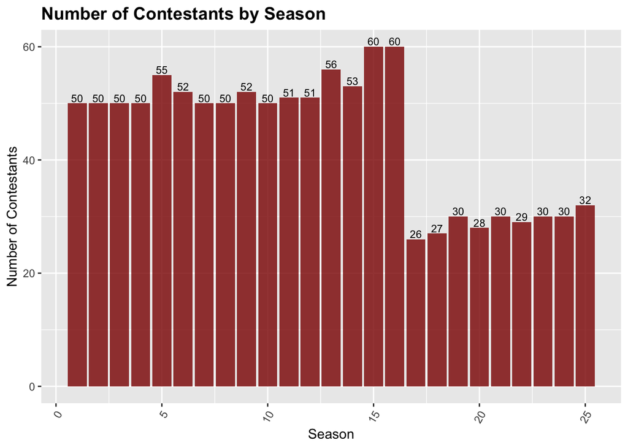

```r
contestants%>%
ggplot(aes(x=season))+
  geom_bar(fill = "darkred", alpha=0.8)+
  labs(title="Number of Contestants by Season", x="Season", y="Number of Contestants")+
  theme(axis.text.x = element_text(angle = 60, hjust = 1),
        plot.title = element_text(size = 14, face="bold"))+
  geom_text(stat = "count", aes(label = ..count..), vjust = -0.2, size = 3, color = "black")
```

Data set 4 which shows more eliminations:

```r
compact_eliminations <- read.csv("data/eliminations_and_dates_compact.csv")
```

8. Build an app that shows all of the couples that are still together:

```r
library(tidyverse)
library(RColorBrewer)
library(paletteer)
library(janitor)
library(here)
library(shiny)
library(shinydashboard)
library(lubridate)
```

App for the Bachelorette

```r
ui <- fluidPage(titlePanel("The Bachelor and The Bachelorette"),
                radioButtons("x", "Select Fill Variable", choices=c("Bachelor", "Bachelorette"), selected="Bachelor"),
                plotOutput("plot", width="600px", height="500px")
)

server <- function(input, output, session) {
  output$plot <- renderPlot({
  ggplot(Bachelor, aes(x=season, y=full_name))+
  geom_col(fill = "darkred", alpha=0.8)+
  coord_flip()+
  labs(title="Couples Still Together by Season", x="Season", y="Couples")+
  theme(axis.text.x = element_text(angle = 60, hjust = 1),
        plot.title = element_text(size = 14, face="bold"))+
  geom_text(aes(label = season), vjust = -0.2, size = 3, color = "black")
  })

  output$plot <- renderPlot({
  ggplot(Bachelorette, aes(x=season, y=full_name))+
  geom_col(fill = "darkred", alpha=0.8)+
  coord_flip()+
  labs(title="Couples Still Together by Season", x="Season", y="Couples")+
  theme(axis.text.x = element_text(angle = 60, hjust = 1),
        plot.title = element_text(size = 14, face="bold"))+
  geom_text(aes(label = season), vjust = -0.2, size = 3, color = "black")
})
}
shinyApp(ui, server)
```

Shiny applications not supported in static R Markdown documents

App for the Bachelor

```r
ui <- fluidPage(titlePanel("The Bachelor and The Bachelorette"),
                radioButtons("x", "Select Fill Variable", choices=c("Bachelor", "Bachelorette"), selected="Bachelor"),
                plotOutput("plot", width="600px", height="500px")
)

server <- function(input, output, session) {
  output$plot <- renderPlot({
  ggplot(Bachelor, aes(x=season, y=full_name))+
  geom_col(fill = "darkred", alpha=0.8)+
  coord_flip()+
  labs(title="Couples Still Together by Season", x="Season", y="Couples")+
  theme(axis.text.x = element_text(angle = 60, hjust = 1),
        plot.title = element_text(size = 14, face="bold"))+
  geom_text(aes(label = season), vjust = -0.2, size = 3, color = "black")
  })

}

shinyApp(ui, server)
```

Shiny applications not supported in static R Markdown documents